# Risk Factor Analysis

## Outcome Variable

**Outcome Variable:** stunted

## Predictor Variables

**Intervention Variable:** perdiar6

**Adjustment Set:**

- arm
- sex
- W_mage
- meducyrs
- W_mhtcm
- W_mwtkg
- W_mbmi
- W_birthwt
- W_birthlen
- W_nrooms
- month
- brthmon
- impfloor
- impsan
- safeh20
- delta_W_mage
- delta_meducyrs
- delta_W_mhtcm
- delta_W_mwtkg
- delta_W_mbmi
- delta_W_birthwt
- delta_W_birthlen
- delta_W_nrooms
- delta_month
- delta_brthmon
- delta_impfloor
- delta_impsan
- delta_safeh20

## Stratifying Variables

The analysis was stratified on these variable(s):

- agecat
- studyid
- country

## Data Summary

| agecat | studyid | country | perdiar6 | stunted | n_cell | n |
| --- | --- | --- | --- | --- | --- | --- |
| Birth | ki0047075b-MAL-ED | BANGLADESH | 0% | 0 | 71 | 257 |
| Birth | ki0047075b-MAL-ED | BANGLADESH | 0% | 1 | 15 | 257 |
| Birth | ki0047075b-MAL-ED | BANGLADESH | (0%, 5%] | 0 | 83 | 257 |
| Birth | ki0047075b-MAL-ED | BANGLADESH | (0%, 5%] | 1 | 13 | 257 |
| Birth | ki0047075b-MAL-ED | BANGLADESH | >5% | 0 | 56 | 257 |
| Birth | ki0047075b-MAL-ED | BANGLADESH | >5% | 1 | 19 | 257 |
| Birth | ki0047075b-MAL-ED | BRAZIL | 0% | 0 | 156 | 191 |
| Birth | ki0047075b-MAL-ED | BRAZIL | 0% | 1 | 20 | 191 |
| Birth | ki0047075b-MAL-ED | BRAZIL | (0%, 5%] | 0 | 12 | 191 |
| Birth | ki0047075b-MAL-ED | BRAZIL | (0%, 5%] | 1 | 1 | 191 |
| Birth | ki0047075b-MAL-ED | BRAZIL | >5% | 0 | 2 | 191 |
| Birth | ki0047075b-MAL-ED | BRAZIL | >5% | 1 | 0 | 191 |
| Birth | ki0047075b-MAL-ED | INDIA | 0% | 0 | 37 | 206 |
| Birth | ki0047075b-MAL-ED | INDIA | 0% | 1 | 10 | 206 |
| Birth | ki0047075b-MAL-ED | INDIA | (0%, 5%] | 0 | 90 | 206 |
| Birth | ki0047075b-MAL-ED | INDIA | (0%, 5%] | 1 | 19 | 206 |
| Birth | ki0047075b-MAL-ED | INDIA | >5% | 0 | 46 | 206 |
| Birth | ki0047075b-MAL-ED | INDIA | >5% | 1 | 4 | 206 |
| Birth | ki0047075b-MAL-ED | NEPAL | 0% | 0 | 55 | 173 |
| Birth | ki0047075b-MAL-ED | NEPAL | 0% | 1 | 5 | 173 |
| Birth | ki0047075b-MAL-ED | NEPAL | (0%, 5%] | 0 | 53 | 173 |
| Birth | ki0047075b-MAL-ED | NEPAL | (0%, 5%] | 1 | 4 | 173 |
| Birth | ki0047075b-MAL-ED | NEPAL | >5% | 0 | 47 | 173 |
| Birth | ki0047075b-MAL-ED | NEPAL | >5% | 1 | 9 | 173 |
| Birth | ki0047075b-MAL-ED | PERU | 0% | 0 | 71 | 287 |
| Birth | ki0047075b-MAL-ED | PERU | 0% | 1 | 12 | 287 |
| Birth | ki0047075b-MAL-ED | PERU | (0%, 5%] | 0 | 76 | 287 |
| Birth | ki0047075b-MAL-ED | PERU | (0%, 5%] | 1 | 12 | 287 |
| Birth | ki0047075b-MAL-ED | PERU | >5% | 0 | 106 | 287 |
| Birth | ki0047075b-MAL-ED | PERU | >5% | 1 | 10 | 287 |

[output cut: 234 more lines]

The following strata were considered:

- agecat: 24 months, studyid: ki0047075b-MAL-ED, country: BANGLADESH
- agecat: 24 months, studyid: ki0047075b-MAL-ED, country: BRAZIL
- agecat: 24 months, studyid: ki0047075b-MAL-ED, country: INDIA
- agecat: 24 months, studyid: ki0047075b-MAL-ED, country: NEPAL
- agecat: 24 months, studyid: ki0047075b-MAL-ED, country: PERU
- agecat: 24 months, studyid: ki0047075b-MAL-ED, country: SOUTH AFRICA
- agecat: 24 months, studyid: ki0047075b-MAL-ED, country: TANZANIA, UNITED REPUBLIC OF
- agecat: 24 months, studyid: ki1017093-NIH-Birth, country: BANGLADESH
- agecat: 24 months, studyid: ki1017093b-PROVIDE, country: BANGLADESH
- agecat: 24 months, studyid: ki1017093c-NIH-Crypto, country: BANGLADESH
- agecat: 24 months, studyid: ki1114097-CMIN, country: BANGLADESH
- agecat: 24 months, studyid: ki1114097-CMIN, country: GUINEA-BISSAU
- agecat: 24 months, studyid: ki1114097-CMIN, country: PERU
- agecat: 24 months, studyid: ki1114097-CONTENT, country: PERU
- agecat: 6 months, studyid: ki0047075b-MAL-ED, country: BANGLADESH
- agecat: 6 months, studyid: ki0047075b-MAL-ED, country: BRAZIL
- agecat: 6 months, studyid: ki0047075b-MAL-ED, country: INDIA
- agecat: 6 months, studyid: ki0047075b-MAL-ED, country: NEPAL
- agecat: 6 months, studyid: ki0047075b-MAL-ED, country: PERU
- agecat: 6 months, studyid: ki0047075b-MAL-ED, country: SOUTH AFRICA
- agecat: 6 months, studyid: ki0047075b-MAL-ED, country: TANZANIA, UNITED REPUBLIC OF
- agecat: 6 months, studyid: ki1000109-ResPak, country: PAKISTAN
- agecat: 6 months, studyid: ki1017093-NIH-Birth, country: BANGLADESH
- agecat: 6 months, studyid: ki1017093b-PROVIDE, country: BANGLADESH
- agecat: 6 months, studyid: ki1017093c-NIH-Crypto, country: BANGLADESH
- agecat: 6 months, studyid: ki1114097-CMIN, country: BANGLADESH
- agecat: 6 months, studyid: ki1114097-CMIN, country: BRAZIL
- agecat: 6 months, studyid: ki1114097-CMIN, country: GUINEA-BISSAU
- agecat: 6 months, studyid: ki1114097-CMIN, country: PERU
- agecat: 6 months, studyid: ki1114097-CONTENT, country: PERU
- agecat: Birth, studyid: ki0047075b-MAL-ED, country: BANGLADESH
- agecat: Birth, studyid: ki0047075b-MAL-ED, country: BRAZIL
- agecat: Birth, studyid: ki0047075b-MAL-ED, country: INDIA
- agecat: Birth, studyid: ki0047075b-MAL-ED, country: NEPAL
- agecat: Birth, studyid: ki0047075b-MAL-ED, country: PERU
- agecat: Birth, studyid: ki0047075b-MAL-ED, country: SOUTH AFRICA
- agecat: Birth, studyid: ki0047075b-MAL-ED, country: TANZANIA, UNITED REPUBLIC OF
- agecat: Birth, studyid: ki1000109-ResPak, country: PAKISTAN
- agecat: Birth, studyid: ki1017093-NIH-Birth, country: BANGLADESH
- agecat: Birth, studyid: ki1017093c-NIH-Crypto, country: BANGLADESH
- agecat: Birth, studyid: ki1114097-CMIN, country: BANGLADESH
- agecat: Birth, studyid: ki1114097-CMIN, country: BRAZIL
- agecat: Birth, studyid: ki1114097-CMIN, country: PERU
- agecat: Birth, studyid: ki1114097-CONTENT, country: PERU

### Dropped Strata

Some strata were dropped due to rare outcomes:

- agecat: Birth, studyid: ki0047075b-MAL-ED, country: BRAZIL
- agecat: Birth, studyid: ki0047075b-MAL-ED, country: INDIA
- agecat: Birth, studyid: ki0047075b-MAL-ED, country: NEPAL
- agecat: Birth, studyid: ki0047075b-MAL-ED, country: SOUTH AFRICA
- agecat: Birth, studyid: ki0047075b-MAL-ED, country: TANZANIA, UNITED REPUBLIC OF
- agecat: Birth, studyid: ki1000109-ResPak, country: PAKISTAN
- agecat: Birth, studyid: ki1017093-NIH-Birth, country: BANGLADESH
- agecat: Birth, studyid: ki1017093c-NIH-Crypto, country: BANGLADESH
- agecat: Birth, studyid: ki1114097-CMIN, country: BANGLADESH
- agecat: Birth, studyid: ki1114097-CMIN, country: BRAZIL
- agecat: Birth, studyid: ki1114097-CMIN, country: PERU
- agecat: Birth, studyid: ki1114097-CONTENT, country: PERU
- agecat: 6 months, studyid: ki0047075b-MAL-ED, country: BRAZIL
- agecat: 6 months, studyid: ki0047075b-MAL-ED, country: NEPAL
- agecat: 6 months, studyid: ki0047075b-MAL-ED, country: SOUTH AFRICA
- agecat: 6 months, studyid: ki1114097-CMIN, country: BRAZIL
- agecat: 6 months, studyid: ki1114097-CONTENT, country: PERU
- agecat: 24 months, studyid: ki0047075b-MAL-ED, country: BRAZIL
- agecat: 24 months, studyid: ki0047075b-MAL-ED, country: SOUTH AFRICA
- agecat: 24 months, studyid: ki1114097-CONTENT, country: PERU

## Methods Detail

We’re interested in the causal parameters $E[Y_a]$ for all values of $a \in \mathcal{A}$. These parameters represent the mean outcome if, possibly contrary to fact, we intervened to set all units to have $A=a$. Under the randomization and positivity assumptions, these are identified by the statistical parameters $\psi_a=E_W[E_{Y|A,W}(Y|A=a,W)]$. In addition, we’re interested in the mean of $Y$, $E[Y]$ under no intervention (the observed mean). We will estimate these parameters by using SuperLearner to fit the relevant likelihood factors – $E_{Y|A,W}(Y|A=a,W)$ and $p(A=a|W)$, and then updating our likelihood fit using a joint TMLE.

For unadjusted analyses ($W=\{\}$), initial likelihoods were estimated using Lrnr_glm to estimate the simple $E(Y|A)$ and Lrnr_mean to estimate $p(A)$. For adjusted analyses, a small library containing Lrnr_glmnet, Lrnr_xgboost, and Lrnr_mean was used.

Having estimated these parameters, we will then use the delta method to estimate relative risks and attributable risks relative to a prespecified baseline level of $A$.

# Results Detail

## Results Plots

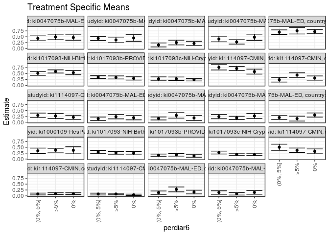

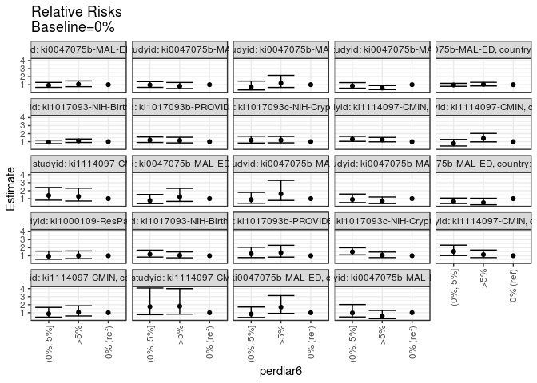

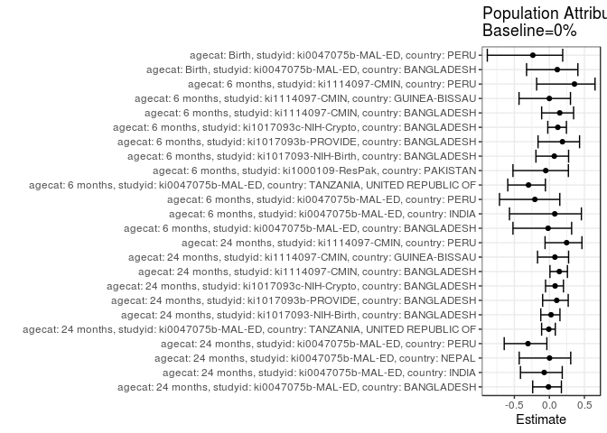

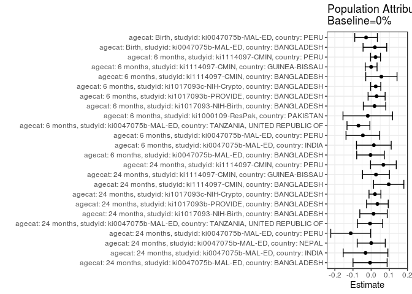

## Results Table

### Parameter: TSM

| agecat | studyid | country | intervention_level | baseline_level | estimate | ci_lower | ci_upper |
| --- | --- | --- | --- | --- | --- | --- | --- |
| Birth | ki0047075b-MAL-ED | BANGLADESH | 0% | NA | 0.1622107 | 0.0835292 | 0.2408922 |
| Birth | ki0047075b-MAL-ED | BANGLADESH | (0%, 5%] | NA | 0.1354455 | 0.0640769 | 0.2068142 |
| Birth | ki0047075b-MAL-ED | BANGLADESH | >5% | NA | 0.2744045 | 0.1705216 | 0.3782873 |
| Birth | ki0047075b-MAL-ED | PERU | 0% | NA | 0.1464278 | 0.0701634 | 0.2226922 |
| Birth | ki0047075b-MAL-ED | PERU | (0%, 5%] | NA | 0.1418503 | 0.0688506 | 0.2148500 |
| Birth | ki0047075b-MAL-ED | PERU | >5% | NA | 0.0851798 | 0.0343272 | 0.1360325 |
| 6 months | ki0047075b-MAL-ED | BANGLADESH | 0% | NA | 0.1901815 | 0.0985720 | 0.2817909 |
| 6 months | ki0047075b-MAL-ED | BANGLADESH | (0%, 5%] | NA | 0.1453981 | 0.0726726 | 0.2181236 |
| 6 months | ki0047075b-MAL-ED | BANGLADESH | >5% | NA | 0.2344069 | 0.1410260 | 0.3277879 |
| 6 months | ki0047075b-MAL-ED | INDIA | 0% | NA | 0.1800000 | 0.0732843 | 0.2867157 |
| 6 months | ki0047075b-MAL-ED | INDIA | (0%, 5%] | NA | 0.1574803 | 0.0939953 | 0.2209654 |
| 6 months | ki0047075b-MAL-ED | INDIA | >5% | NA | 0.2881356 | 0.1723269 | 0.4039443 |
| 6 months | ki0047075b-MAL-ED | PERU | 0% | NA | 0.2653382 | 0.1571993 | 0.3734770 |
| 6 months | ki0047075b-MAL-ED | PERU | (0%, 5%] | NA | 0.2378085 | 0.1460693 | 0.3295477 |
| 6 months | ki0047075b-MAL-ED | PERU | >5% | NA | 0.1818644 | 0.1114456 | 0.2522832 |
| 6 months | ki0047075b-MAL-ED | TANZANIA, UNITED REPUBLIC OF | 0% | NA | 0.3047619 | 0.2165390 | 0.3929848 |
| 6 months | ki0047075b-MAL-ED | TANZANIA, UNITED REPUBLIC OF | (0%, 5%] | NA | 0.1979167 | 0.1180539 | 0.2777794 |
| 6 months | ki0047075b-MAL-ED | TANZANIA, UNITED REPUBLIC OF | >5% | NA | 0.1521739 | 0.0481643 | 0.2561836 |
| 6 months | ki1000109-ResPak | PAKISTAN | 0% | NA | 0.3716937 | 0.2218536 | 0.5215339 |
| 6 months | ki1000109-ResPak | PAKISTAN | (0%, 5%] | NA | 0.3476767 | 0.2307922 | 0.4645611 |
| 6 months | ki1000109-ResPak | PAKISTAN | >5% | NA | 0.3743489 | 0.2911220 | 0.4575759 |
| 6 months | ki1017093-NIH-Birth | BANGLADESH | 0% | NA | 0.2494048 | 0.1782130 | 0.3205966 |
| 6 months | ki1017093-NIH-Birth | BANGLADESH | (0%, 5%] | NA | 0.2956675 | 0.2289433 | 0.3623916 |
| 6 months | ki1017093-NIH-Birth | BANGLADESH | >5% | NA | 0.2603746 | 0.2050368 | 0.3157123 |
| 6 months | ki1017093b-PROVIDE | BANGLADESH | 0% | NA | 0.1311379 | 0.0779151 | 0.1843607 |
| 6 months | ki1017093b-PROVIDE | BANGLADESH | (0%, 5%] | NA | 0.1644985 | 0.1175770 | 0.2114199 |
| 6 months | ki1017093b-PROVIDE | BANGLADESH | >5% | NA | 0.1806762 | 0.1241080 | 0.2372445 |
| 6 months | ki1017093c-NIH-Crypto | BANGLADESH | 0% | NA | 0.1845996 | 0.1456567 | 0.2235426 |
| 6 months | ki1017093c-NIH-Crypto | BANGLADESH | (0%, 5%] | NA | 0.2751202 | 0.2135410 | 0.3366994 |
| 6 months | ki1017093c-NIH-Crypto | BANGLADESH | >5% | NA | 0.1951805 | 0.1432014 | 0.2471596 |
| 6 months | ki1114097-CMIN | BANGLADESH | 0% | NA | 0.3262636 | 0.2230734 | 0.4294538 |
| 6 months | ki1114097-CMIN | BANGLADESH | (0%, 5%] | NA | 0.5013018 | 0.3709165 | 0.6316872 |
| 6 months | ki1114097-CMIN | BANGLADESH | >5% | NA | 0.3724782 | 0.2782813 | 0.4666751 |
| 6 months | ki1114097-CMIN | GUINEA-BISSAU | 0% | NA | 0.0908455 | 0.0511628 | 0.1305282 |
| 6 months | ki1114097-CMIN | GUINEA-BISSAU | (0%, 5%] | NA | 0.0783315 | 0.0398112 | 0.1168519 |
| 6 months | ki1114097-CMIN | GUINEA-BISSAU | >5% | NA | 0.0953506 | 0.0599472 | 0.1307540 |
| 6 months | ki1114097-CMIN | PERU | 0% | NA | 0.0434783 | 0.0139889 | 0.0729676 |
| 6 months | ki1114097-CMIN | PERU | (0%, 5%] | NA | 0.0760870 | 0.0377470 | 0.1144270 |
| 6 months | ki1114097-CMIN | PERU | >5% | NA | 0.0786517 | 0.0463369 | 0.1109664 |
| 24 months | ki0047075b-MAL-ED | BANGLADESH | 0% | NA | 0.4682026 | 0.3531853 | 0.5832199 |
| 24 months | ki0047075b-MAL-ED | BANGLADESH | (0%, 5%] | NA | 0.4333357 | 0.3292844 | 0.5373870 |
| 24 months | ki0047075b-MAL-ED | BANGLADESH | >5% | NA | 0.4928727 | 0.3738166 | 0.6119288 |
| 24 months | ki0047075b-MAL-ED | INDIA | 0% | NA | 0.4494754 | 0.3093936 | 0.5895573 |
| 24 months | ki0047075b-MAL-ED | INDIA | (0%, 5%] | NA | 0.4312266 | 0.3444721 | 0.5179811 |
| 24 months | ki0047075b-MAL-ED | INDIA | >5% | NA | 0.3656838 | 0.2442453 | 0.4871223 |
| 24 months | ki0047075b-MAL-ED | NEPAL | 0% | NA | 0.2143995 | 0.1191689 | 0.3096301 |
| 24 months | ki0047075b-MAL-ED | NEPAL | (0%, 5%] | NA | 0.1514395 | 0.0668855 | 0.2359935 |
| 24 months | ki0047075b-MAL-ED | NEPAL | >5% | NA | 0.2550477 | 0.1540818 | 0.3560136 |
| 24 months | ki0047075b-MAL-ED | PERU | 0% | NA | 0.4805763 | 0.3494746 | 0.6116779 |
| 24 months | ki0047075b-MAL-ED | PERU | (0%, 5%] | NA | 0.4054516 | 0.2849377 | 0.5259656 |
| 24 months | ki0047075b-MAL-ED | PERU | >5% | NA | 0.2815931 | 0.1896390 | 0.3735471 |
| 24 months | ki0047075b-MAL-ED | TANZANIA, UNITED REPUBLIC OF | 0% | NA | 0.7209595 | 0.6284971 | 0.8134218 |
| 24 months | ki0047075b-MAL-ED | TANZANIA, UNITED REPUBLIC OF | (0%, 5%] | NA | 0.6946101 | 0.5963915 | 0.7928287 |
| 24 months | ki0047075b-MAL-ED | TANZANIA, UNITED REPUBLIC OF | >5% | NA | 0.7538250 | 0.6178665 | 0.8897835 |
| 24 months | ki1017093-NIH-Birth | BANGLADESH | 0% | NA | 0.5416076 | 0.4524244 | 0.6307908 |
| 24 months | ki1017093-NIH-Birth | BANGLADESH | (0%, 5%] | NA | 0.5120872 | 0.4274545 | 0.5967200 |
| 24 months | ki1017093-NIH-Birth | BANGLADESH | >5% | NA | 0.5929321 | 0.5259747 | 0.6598896 |
| 24 months | ki1017093b-PROVIDE | BANGLADESH | 0% | NA | 0.2947957 | 0.2247424 | 0.3648491 |
| 24 months | ki1017093b-PROVIDE | BANGLADESH | (0%, 5%] | NA | 0.3524915 | 0.2945978 | 0.4103853 |
| 24 months | ki1017093b-PROVIDE | BANGLADESH | >5% | NA | 0.3373742 | 0.2720150 | 0.4027335 |
| 24 months | ki1017093c-NIH-Crypto | BANGLADESH | 0% | NA | 0.2357921 | 0.1873728 | 0.2842114 |
| 24 months | ki1017093c-NIH-Crypto | BANGLADESH | (0%, 5%] | NA | 0.2779895 | 0.1955749 | 0.3604041 |
| 24 months | ki1017093c-NIH-Crypto | BANGLADESH | >5% | NA | 0.2797439 | 0.2042587 | 0.3552290 |
| 24 months | ki1114097-CMIN | BANGLADESH | 0% | NA | 0.5850485 | 0.4784205 | 0.6916766 |
| 24 months | ki1114097-CMIN | BANGLADESH | (0%, 5%] | NA | 0.7673248 | 0.6549463 | 0.8797032 |
| 24 months | ki1114097-CMIN | BANGLADESH | >5% | NA | 0.7178125 | 0.6275272 | 0.8080979 |
| 24 months | ki1114097-CMIN | GUINEA-BISSAU | 0% | NA | 0.3103501 | 0.2201616 | 0.4005385 |
| 24 months | ki1114097-CMIN | GUINEA-BISSAU | (0%, 5%] | NA | 0.2395913 | 0.1404504 | 0.3387322 |
| 24 months | ki1114097-CMIN | GUINEA-BISSAU | >5% | NA | 0.4373103 | 0.3402795 | 0.5343410 |
| 24 months | ki1114097-CMIN | PERU | 0% | NA | 0.2070802 | 0.1209902 | 0.2931702 |
| 24 months | ki1114097-CMIN | PERU | (0%, 5%] | NA | 0.2892209 | 0.1904896 | 0.3879521 |
| 24 months | ki1114097-CMIN | PERU | >5% | NA | 0.2648113 | 0.1544405 | 0.3751821 |

### Parameter: E(Y)

| agecat | studyid | country | intervention_level | baseline_level | estimate | ci_lower | ci_upper |
| --- | --- | --- | --- | --- | --- | --- | --- |
| Birth | ki0047075b-MAL-ED | BANGLADESH | NA | NA | 0.1828794 | 0.1355257 | 0.2302330 |
| Birth | ki0047075b-MAL-ED | PERU | NA | NA | 0.1184669 | 0.0810142 | 0.1559196 |
| 6 months | ki0047075b-MAL-ED | BANGLADESH | NA | NA | 0.1867220 | 0.1374205 | 0.2360234 |
| 6 months | ki0047075b-MAL-ED | INDIA | NA | NA | 0.1949153 | 0.1442678 | 0.2455627 |
| 6 months | ki0047075b-MAL-ED | PERU | NA | NA | 0.2197802 | 0.1705687 | 0.2689917 |
| 6 months | ki0047075b-MAL-ED | TANZANIA, UNITED REPUBLIC OF | NA | NA | 0.2348178 | 0.1818480 | 0.2877876 |
| 6 months | ki1000109-ResPak | PAKISTAN | NA | NA | 0.3531915 | 0.2919518 | 0.4144312 |
| 6 months | ki1017093-NIH-Birth | BANGLADESH | NA | NA | 0.2681564 | 0.2306532 | 0.3056597 |
| 6 months | ki1017093b-PROVIDE | BANGLADESH | NA | NA | 0.1612350 | 0.1313580 | 0.1911120 |
| 6 months | ki1017093c-NIH-Crypto | BANGLADESH | NA | NA | 0.2097902 | 0.1799252 | 0.2396552 |
| 6 months | ki1114097-CMIN | BANGLADESH | NA | NA | 0.3827160 | 0.3214780 | 0.4439541 |
| 6 months | ki1114097-CMIN | GUINEA-BISSAU | NA | NA | 0.0907738 | 0.0690366 | 0.1125110 |
| 6 months | ki1114097-CMIN | PERU | NA | NA | 0.0677165 | 0.0481585 | 0.0872746 |
| 24 months | ki0047075b-MAL-ED | BANGLADESH | NA | NA | 0.4622642 | 0.3949918 | 0.5295365 |
| 24 months | ki0047075b-MAL-ED | INDIA | NA | NA | 0.4185022 | 0.3541865 | 0.4828179 |
| 24 months | ki0047075b-MAL-ED | NEPAL | NA | NA | 0.2149123 | 0.1614774 | 0.2683472 |
| 24 months | ki0047075b-MAL-ED | PERU | NA | NA | 0.3681592 | 0.3013164 | 0.4350020 |
| 24 months | ki0047075b-MAL-ED | TANZANIA, UNITED REPUBLIC OF | NA | NA | 0.7149533 | 0.6543278 | 0.7755787 |
| 24 months | ki1017093-NIH-Birth | BANGLADESH | NA | NA | 0.5547786 | 0.5076945 | 0.6018626 |
| 24 months | ki1017093b-PROVIDE | BANGLADESH | NA | NA | 0.3292894 | 0.2909105 | 0.3676684 |
| 24 months | ki1017093c-NIH-Crypto | BANGLADESH | NA | NA | 0.2568093 | 0.2190047 | 0.2946140 |
| 24 months | ki1114097-CMIN | BANGLADESH | NA | NA | 0.6818182 | 0.6230135 | 0.7406228 |
| 24 months | ki1114097-CMIN | GUINEA-BISSAU | NA | NA | 0.3369176 | 0.2813564 | 0.3924787 |
| 24 months | ki1114097-CMIN | PERU | NA | NA | 0.2745902 | 0.2184751 | 0.3307052 |

### Parameter: RR

| agecat | studyid | country | intervention_level | baseline_level | estimate | ci_lower | ci_upper |
| --- | --- | --- | --- | --- | --- | --- | --- |
| Birth | ki0047075b-MAL-ED | BANGLADESH | 0% | 0% | 1.0000000 | 1.0000000 | 1.0000000 |
| Birth | ki0047075b-MAL-ED | BANGLADESH | (0%, 5%] | 0% | 0.8349973 | 0.4078997 | 1.7092940 |
| Birth | ki0047075b-MAL-ED | BANGLADESH | >5% | 0% | 1.6916542 | 0.9139738 | 3.1310458 |
| Birth | ki0047075b-MAL-ED | PERU | 0% | 0% | 1.0000000 | 1.0000000 | 1.0000000 |
| Birth | ki0047075b-MAL-ED | PERU | (0%, 5%] | 0% | 0.9687388 | 0.4657177 | 2.0150723 |
| Birth | ki0047075b-MAL-ED | PERU | >5% | 0% | 0.5817191 | 0.2636096 | 1.2837057 |
| 6 months | ki0047075b-MAL-ED | BANGLADESH | 0% | 0% | 1.0000000 | 1.0000000 | 1.0000000 |
| 6 months | ki0047075b-MAL-ED | BANGLADESH | (0%, 5%] | 0% | 0.7645230 | 0.3830737 | 1.5258039 |
| 6 months | ki0047075b-MAL-ED | BANGLADESH | >5% | 0% | 1.2325437 | 0.6622292 | 2.2940152 |
| 6 months | ki0047075b-MAL-ED | INDIA | 0% | 0% | 1.0000000 | 1.0000000 | 1.0000000 |
| 6 months | ki0047075b-MAL-ED | INDIA | (0%, 5%] | 0% | 0.8748906 | 0.4271602 | 1.7919125 |
| 6 months | ki0047075b-MAL-ED | INDIA | >5% | 0% | 1.6007533 | 0.7820878 | 3.2763728 |
| 6 months | ki0047075b-MAL-ED | PERU | 0% | 0% | 1.0000000 | 1.0000000 | 1.0000000 |
| 6 months | ki0047075b-MAL-ED | PERU | (0%, 5%] | 0% | 0.8962468 | 0.5108250 | 1.5724725 |
| 6 months | ki0047075b-MAL-ED | PERU | >5% | 0% | 0.6854061 | 0.3909470 | 1.2016502 |
| 6 months | ki0047075b-MAL-ED | TANZANIA, UNITED REPUBLIC OF | 0% | 0% | 1.0000000 | 1.0000000 | 1.0000000 |
| 6 months | ki0047075b-MAL-ED | TANZANIA, UNITED REPUBLIC OF | (0%, 5%] | 0% | 0.6494141 | 0.3952255 | 1.0670837 |
| 6 months | ki0047075b-MAL-ED | TANZANIA, UNITED REPUBLIC OF | >5% | 0% | 0.4993207 | 0.2376933 | 1.0489194 |
| 6 months | ki1000109-ResPak | PAKISTAN | 0% | 0% | 1.0000000 | 1.0000000 | 1.0000000 |
| 6 months | ki1000109-ResPak | PAKISTAN | (0%, 5%] | 0% | 0.9353848 | 0.5545516 | 1.5777516 |
| 6 months | ki1000109-ResPak | PAKISTAN | >5% | 0% | 1.0071436 | 0.6347599 | 1.5979871 |
| 6 months | ki1017093-NIH-Birth | BANGLADESH | 0% | 0% | 1.0000000 | 1.0000000 | 1.0000000 |
| 6 months | ki1017093-NIH-Birth | BANGLADESH | (0%, 5%] | 0% | 1.1854922 | 0.8285121 | 1.6962839 |
| 6 months | ki1017093-NIH-Birth | BANGLADESH | >5% | 0% | 1.0439838 | 0.7364885 | 1.4798633 |
| 6 months | ki1017093b-PROVIDE | BANGLADESH | 0% | 0% | 1.0000000 | 1.0000000 | 1.0000000 |
| 6 months | ki1017093b-PROVIDE | BANGLADESH | (0%, 5%] | 0% | 1.2543927 | 0.7650238 | 2.0568000 |
| 6 months | ki1017093b-PROVIDE | BANGLADESH | >5% | 0% | 1.3777572 | 0.8258464 | 2.2985083 |
| 6 months | ki1017093c-NIH-Crypto | BANGLADESH | 0% | 0% | 1.0000000 | 1.0000000 | 1.0000000 |
| 6 months | ki1017093c-NIH-Crypto | BANGLADESH | (0%, 5%] | 0% | 1.4903616 | 1.1109064 | 1.9994283 |
| 6 months | ki1017093c-NIH-Crypto | BANGLADESH | >5% | 0% | 1.0573178 | 0.7627663 | 1.4656140 |
| 6 months | ki1114097-CMIN | BANGLADESH | 0% | 0% | 1.0000000 | 1.0000000 | 1.0000000 |
| 6 months | ki1114097-CMIN | BANGLADESH | (0%, 5%] | 0% | 1.5364931 | 1.0190517 | 2.3166745 |
| 6 months | ki1114097-CMIN | BANGLADESH | >5% | 0% | 1.1416479 | 0.7613331 | 1.7119443 |
| 6 months | ki1114097-CMIN | GUINEA-BISSAU | 0% | 0% | 1.0000000 | 1.0000000 | 1.0000000 |
| 6 months | ki1114097-CMIN | GUINEA-BISSAU | (0%, 5%] | 0% | 0.8622500 | 0.4467228 | 1.6642872 |
| 6 months | ki1114097-CMIN | GUINEA-BISSAU | >5% | 0% | 1.0495911 | 0.5913830 | 1.8628223 |
| 6 months | ki1114097-CMIN | PERU | 0% | 0% | 1.0000000 | 1.0000000 | 1.0000000 |
| 6 months | ki1114097-CMIN | PERU | (0%, 5%] | 0% | 1.7499999 | 0.7517625 | 4.0737598 |
| 6 months | ki1114097-CMIN | PERU | >5% | 0% | 1.8089887 | 0.8185484 | 3.9978577 |
| 24 months | ki0047075b-MAL-ED | BANGLADESH | 0% | 0% | 1.0000000 | 1.0000000 | 1.0000000 |
| 24 months | ki0047075b-MAL-ED | BANGLADESH | (0%, 5%] | 0% | 0.9255303 | 0.6667957 | 1.2846608 |
| 24 months | ki0047075b-MAL-ED | BANGLADESH | >5% | 0% | 1.0526910 | 0.7536999 | 1.4702912 |
| 24 months | ki0047075b-MAL-ED | INDIA | 0% | 0% | 1.0000000 | 1.0000000 | 1.0000000 |
| 24 months | ki0047075b-MAL-ED | INDIA | (0%, 5%] | 0% | 0.9593998 | 0.6659280 | 1.3822034 |
| 24 months | ki0047075b-MAL-ED | INDIA | >5% | 0% | 0.8135790 | 0.5190068 | 1.2753414 |
| 24 months | ki0047075b-MAL-ED | NEPAL | 0% | 0% | 1.0000000 | 1.0000000 | 1.0000000 |
| 24 months | ki0047075b-MAL-ED | NEPAL | (0%, 5%] | 0% | 0.7063427 | 0.3450225 | 1.4460508 |
| 24 months | ki0047075b-MAL-ED | NEPAL | >5% | 0% | 1.1895913 | 0.6561793 | 2.1566171 |
| 24 months | ki0047075b-MAL-ED | PERU | 0% | 0% | 1.0000000 | 1.0000000 | 1.0000000 |
| 24 months | ki0047075b-MAL-ED | PERU | (0%, 5%] | 0% | 0.8436780 | 0.5661030 | 1.2573552 |
| 24 months | ki0047075b-MAL-ED | PERU | >5% | 0% | 0.5859487 | 0.3867135 | 0.8878301 |
| 24 months | ki0047075b-MAL-ED | TANZANIA, UNITED REPUBLIC OF | 0% | 0% | 1.0000000 | 1.0000000 | 1.0000000 |
| 24 months | ki0047075b-MAL-ED | TANZANIA, UNITED REPUBLIC OF | (0%, 5%] | 0% | 0.9634524 | 0.7958910 | 1.1662910 |
| 24 months | ki0047075b-MAL-ED | TANZANIA, UNITED REPUBLIC OF | >5% | 0% | 1.0455858 | 0.8419465 | 1.2984789 |
| 24 months | ki1017093-NIH-Birth | BANGLADESH | 0% | 0% | 1.0000000 | 1.0000000 | 1.0000000 |
| 24 months | ki1017093-NIH-Birth | BANGLADESH | (0%, 5%] | 0% | 0.9454950 | 0.7540963 | 1.1854730 |
| 24 months | ki1017093-NIH-Birth | BANGLADESH | >5% | 0% | 1.0947633 | 0.9015710 | 1.3293538 |
| 24 months | ki1017093b-PROVIDE | BANGLADESH | 0% | 0% | 1.0000000 | 1.0000000 | 1.0000000 |
| 24 months | ki1017093b-PROVIDE | BANGLADESH | (0%, 5%] | 0% | 1.1957145 | 0.9028925 | 1.5835031 |
| 24 months | ki1017093b-PROVIDE | BANGLADESH | >5% | 0% | 1.1444340 | 0.8460077 | 1.5481291 |
| 24 months | ki1017093c-NIH-Crypto | BANGLADESH | 0% | 0% | 1.0000000 | 1.0000000 | 1.0000000 |
| 24 months | ki1017093c-NIH-Crypto | BANGLADESH | (0%, 5%] | 0% | 1.1789601 | 0.8283286 | 1.6780139 |
| 24 months | ki1017093c-NIH-Crypto | BANGLADESH | >5% | 0% | 1.1864005 | 0.8521198 | 1.6518172 |
| 24 months | ki1114097-CMIN | BANGLADESH | 0% | 0% | 1.0000000 | 1.0000000 | 1.0000000 |
| 24 months | ki1114097-CMIN | BANGLADESH | (0%, 5%] | 0% | 1.3115575 | 1.0385938 | 1.6562616 |
| 24 months | ki1114097-CMIN | BANGLADESH | >5% | 0% | 1.2269282 | 0.9830580 | 1.5312959 |
| 24 months | ki1114097-CMIN | GUINEA-BISSAU | 0% | 0% | 1.0000000 | 1.0000000 | 1.0000000 |
| 24 months | ki1114097-CMIN | GUINEA-BISSAU | (0%, 5%] | 0% | 0.7720034 | 0.4661099 | 1.2786454 |
| 24 months | ki1114097-CMIN | GUINEA-BISSAU | >5% | 0% | 1.4090872 | 0.9777398 | 2.0307313 |
| 24 months | ki1114097-CMIN | PERU | 0% | 0% | 1.0000000 | 1.0000000 | 1.0000000 |
| 24 months | ki1114097-CMIN | PERU | (0%, 5%] | 0% | 1.3966613 | 0.8123092 | 2.4013796 |
| 24 months | ki1114097-CMIN | PERU | >5% | 0% | 1.2787863 | 0.7065281 | 2.3145497 |

### Parameter: PAR

| agecat | studyid | country | intervention_level | baseline_level | estimate | ci_lower | ci_upper |
| --- | --- | --- | --- | --- | --- | --- | --- |
| Birth | ki0047075b-MAL-ED | BANGLADESH | 0% | NA | 0.0206686 | -0.0445602 | 0.0858975 |
| Birth | ki0047075b-MAL-ED | PERU | 0% | NA | -0.0279609 | -0.0902196 | 0.0342978 |
| 6 months | ki0047075b-MAL-ED | BANGLADESH | 0% | NA | -0.0034595 | -0.0796087 | 0.0726898 |
| 6 months | ki0047075b-MAL-ED | INDIA | 0% | NA | 0.0149153 | -0.0806247 | 0.1104552 |
| 6 months | ki0047075b-MAL-ED | PERU | 0% | NA | -0.0455580 | -0.1384010 | 0.0472851 |
| 6 months | ki0047075b-MAL-ED | TANZANIA, UNITED REPUBLIC OF | 0% | NA | -0.0699441 | -0.1329657 | -0.0069225 |
| 6 months | ki1000109-ResPak | PAKISTAN | 0% | NA | -0.0185022 | -0.1551257 | 0.1181212 |
| 6 months | ki1017093-NIH-Birth | BANGLADESH | 0% | NA | 0.0187516 | -0.0431749 | 0.0806782 |
| 6 months | ki1017093b-PROVIDE | BANGLADESH | 0% | NA | 0.0300971 | -0.0168574 | 0.0770516 |
| 6 months | ki1017093c-NIH-Crypto | BANGLADESH | 0% | NA | 0.0251906 | -0.0027210 | 0.0531021 |
| 6 months | ki1114097-CMIN | BANGLADESH | 0% | NA | 0.0564524 | -0.0297187 | 0.1426235 |
| 6 months | ki1114097-CMIN | GUINEA-BISSAU | 0% | NA | -0.0000717 | -0.0326826 | 0.0325393 |
| 6 months | ki1114097-CMIN | PERU | 0% | NA | 0.0242383 | -0.0031144 | 0.0515909 |
| 24 months | ki0047075b-MAL-ED | BANGLADESH | 0% | NA | -0.0059385 | -0.0999518 | 0.0880749 |
| 24 months | ki0047075b-MAL-ED | INDIA | 0% | NA | -0.0309732 | -0.1541714 | 0.0922249 |
| 24 months | ki0047075b-MAL-ED | NEPAL | 0% | NA | 0.0005128 | -0.0767683 | 0.0777940 |
| 24 months | ki0047075b-MAL-ED | PERU | 0% | NA | -0.1124171 | -0.2224449 | -0.0023893 |
| 24 months | ki0047075b-MAL-ED | TANZANIA, UNITED REPUBLIC OF | 0% | NA | -0.0060062 | -0.0757075 | 0.0636952 |
| 24 months | ki1017093-NIH-Birth | BANGLADESH | 0% | NA | 0.0131710 | -0.0623980 | 0.0887399 |
| 24 months | ki1017093b-PROVIDE | BANGLADESH | 0% | NA | 0.0344937 | -0.0251467 | 0.0941341 |
| 24 months | ki1017093c-NIH-Crypto | BANGLADESH | 0% | NA | 0.0210173 | -0.0117392 | 0.0537737 |
| 24 months | ki1114097-CMIN | BANGLADESH | 0% | NA | 0.0967697 | 0.0132746 | 0.1802648 |
| 24 months | ki1114097-CMIN | GUINEA-BISSAU | 0% | NA | 0.0265675 | -0.0474995 | 0.1006345 |
| 24 months | ki1114097-CMIN | PERU | 0% | NA | 0.0675100 | -0.0033335 | 0.1383535 |

### Parameter: PAF

| agecat | studyid | country | intervention_level | baseline_level | estimate | ci_lower | ci_upper |
| --- | --- | --- | --- | --- | --- | --- | --- |
| Birth | ki0047075b-MAL-ED | BANGLADESH | 0% | NA | 0.1130179 | -0.3256605 | 0.4065319 |
| Birth | ki0047075b-MAL-ED | PERU | 0% | NA | -0.2360228 | -0.8858953 | 0.1899061 |
| 6 months | ki0047075b-MAL-ED | BANGLADESH | 0% | NA | -0.0185273 | -0.5199622 | 0.3174844 |
| 6 months | ki0047075b-MAL-ED | INDIA | 0% | NA | 0.0765217 | -0.5697683 | 0.4567274 |
| 6 months | ki0047075b-MAL-ED | PERU | 0% | NA | -0.2072887 | -0.7119759 | 0.1486177 |
| 6 months | ki0047075b-MAL-ED | TANZANIA, UNITED REPUBLIC OF | 0% | NA | -0.2978654 | -0.5939064 | -0.0568089 |
| 6 months | ki1000109-ResPak | PAKISTAN | 0% | NA | -0.0523859 | -0.5200035 | 0.2713727 |
| 6 months | ki1017093-NIH-Birth | BANGLADESH | 0% | NA | 0.0699279 | -0.1920027 | 0.2743019 |
| 6 months | ki1017093b-PROVIDE | BANGLADESH | 0% | NA | 0.1866658 | -0.1617780 | 0.4306034 |
| 6 months | ki1017093c-NIH-Crypto | BANGLADESH | 0% | NA | 0.1200751 | -0.0229895 | 0.2431322 |
| 6 months | ki1114097-CMIN | BANGLADESH | 0% | NA | 0.1475047 | -0.1102610 | 0.3454258 |
| 6 months | ki1114097-CMIN | GUINEA-BISSAU | 0% | NA | -0.0007896 | -0.4329793 | 0.3010507 |
| 6 months | ki1114097-CMIN | PERU | 0% | NA | 0.3579373 | -0.1818406 | 0.6511843 |
| 24 months | ki0047075b-MAL-ED | BANGLADESH | 0% | NA | -0.0128465 | -0.2381138 | 0.1714348 |
| 24 months | ki0047075b-MAL-ED | INDIA | 0% | NA | -0.0740097 | -0.4126828 | 0.1834707 |
| 24 months | ki0047075b-MAL-ED | NEPAL | 0% | NA | 0.0023862 | -0.4305842 | 0.3043168 |
| 24 months | ki0047075b-MAL-ED | PERU | 0% | NA | -0.3053491 | -0.6447323 | -0.0359962 |
| 24 months | ki0047075b-MAL-ED | TANZANIA, UNITED REPUBLIC OF | 0% | NA | -0.0084008 | -0.1107612 | 0.0845268 |
| 24 months | ki1017093-NIH-Birth | BANGLADESH | 0% | NA | 0.0237410 | -0.1224599 | 0.1508991 |
| 24 months | ki1017093b-PROVIDE | BANGLADESH | 0% | NA | 0.1047519 | -0.0960924 | 0.2687942 |
| 24 months | ki1017093c-NIH-Crypto | BANGLADESH | 0% | NA | 0.0818399 | -0.0547682 | 0.2007553 |
| 24 months | ki1114097-CMIN | BANGLADESH | 0% | NA | 0.1419288 | 0.0082553 | 0.2575850 |
| 24 months | ki1114097-CMIN | GUINEA-BISSAU | 0% | NA | 0.0788546 | -0.1690404 | 0.2741836 |
| 24 months | ki1114097-CMIN | PERU | 0% | NA | 0.2458573 | -0.0619252 | 0.4644338 |